# Modelling the invasive American Mink in the Pyrenees

## Propagule pressure and conservation

In this section, we will pivot a little to look at a modern model of invasion, taken from [Catford et al. 2018](http://www.nature.com/articles/s41467-018-04491-3).

The reason that the American mink was introduced to Europe is in order to [farm it for fur](https://en.wikipedia.org/wiki/Fur_farming), and and escaped mink from fur farms can bolster self-sustaining wild populations. This effect is called [propagule pressure](https://en.wikipedia.org/wiki/Propagule_pressure) in invasion science. We will incorporate the propagule pressure in this model as a new parameter

[figure not shown]

for both populations – an equivalent for the endangered native could be a breed and release conservation project.

In this model, we will make the idea of a carrying capacity more concrete by imagining that the area of interest is divided into territories that are occupied by a single member of one of the species. In the case of the mink, these territories are usually 1-6km of riverbank [5], but can also include ponds and coastal areas. The carrying capacity is the number of territories available, and instead of modelling the number of individuals, we will model the number of territories occupied by each species (assuming that if an individual doesn’t have a territory of its own, it will die).

Additionally, we will add a new term that represents per-capita mortality of the mink. Both species have a lifespan of approximately 10 years (although the invasive may have a longer lifespan), so the per-capita mortality rate is

[figure not shown]

(we assume that the only cause of death of an individual which occupies some habitat is [senescence](https://en.wikipedia.org/wiki/Senescence))

Finally, we will think about competition more concretely. There is some evidence that species around the world make *universal trade-offs* (see [Tilman 2011](https://www.journals.uchicago.edu/doi/10.1086/661245)). That is, every species is subject to fundamental biological constraints that limit how many resources they can invest in different axes of competition. In this model, we will assume that there is a tradeoff between fecundity (litter size) and ability to compete for habitat. In this case, we could think of this in terms of resource use between the two species. We know that the European mink produces more offspring and that the American mink is slightly larger, representing a tradeoff in the allocation of biomass acquired from food. Let’s assume that the larger size of the invasive allows it to displace European mink from habitat patches they occupy.

Let’s build our model.

[figure not shown]

Now, these equations are different for the two species (due to differences we outlined above). Each equation has two parts, the first representing colonisation of new territories, and the second part representing loss of territory due to death or displacement. In the case of the native European mink (

[figure not shown]

), the patches available to it for colonisation are only those that are not already occupied by either the native or the invasive. The European mink loses habitat patches only via mortality or displacement from the invasive. In the case of the American mink, it is able to colonise patches that are either empty or occupied by the European mink – since it is competitively dominant. It will only lose patches due to mortality, since the European mink is unable to displace it.

Let’s write this out.

```r
catford <- function(
        X,
        hx = 0,
        hy = 0,    # Propagule pressure -- 0 for now.
        mx = 0.1,
        my = mx   # Mortality rates -- equal for now.
) {
        # Define the parameters.
        K <- 100    # Number of habitat patches
        rx <- log(2.5)
        ry <- log(2)     # Smaller litters for the invader
        # Read the current population values
        x <- X[1]
        y <- X[2]
        # Calculate the equation results.
        res_x <- (rx * x + hx) * (1 - (x + y) / K) - (mx + ry * y / K + hy) * x
        res_y <- (ry * y + hy) * (1 - y / K) - my * y
        return(c(res_x, res_y))
}
```

```r
res <- run_simulation(
        catford,          # Use our model.
        X = c(100, 10),   # Start with 10 invaders, and the natives at carrying capacity.
        N = 20            # Run it for 20 timesteps
)
```

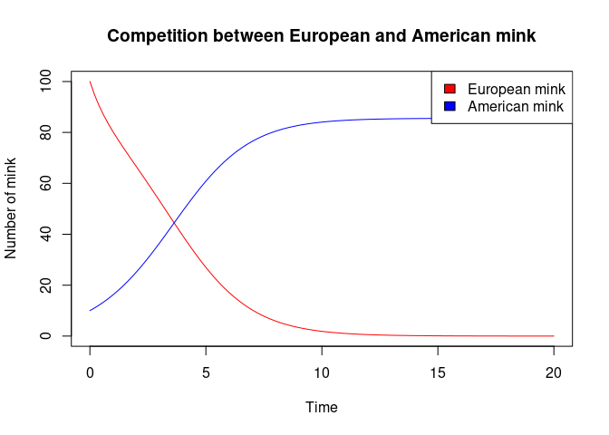

```r
# Plot our results.
plot(
        res[, 1], res[, 2],  # Natives
        type = "l",    # For a line graph
        col = "red",
        xlab = "Time",
        ylab = "Number of mink",
        main = "Competition between European and American mink",
        ylim = c(0, 100)    # Plot the full y-axis
)
lines(res[, 1], res[, 3], col = "blue")  # Invaders
legend(
        "topright",
        legend = c("European mink", "American mink"),
        fill = c("red", "blue")
)
```

Wow, so in this model, we get extinction of the native almost immediately. Now, let’s think about our breed-and-release program – how many European mink would we need to breed and release every timestep to have a viable population of the native?

```r
# Let's run a simulation for values of hx ranging from 1 to 1000, and see
# how many European mink-occupied habitats we have after some time.
hx <- 1:1000
res <- rep(NA, length(hx))    # create a vector to hold the results
for (i in seq_along(hx)) {
        sim_res <- run_simulation(
                # Use our model with the new value of h
                function(X) catford(X, hx = hx[i]),
                X = c(100, 10),   # Start with 10 invaders, and the natives at carrying capacity.
                N = 50            # Run it for 50 timesteps.
        )
        # Store the last value of the native population.
        res[i] <- floor(sim_res[nrow(sim_res), 2])
}
```

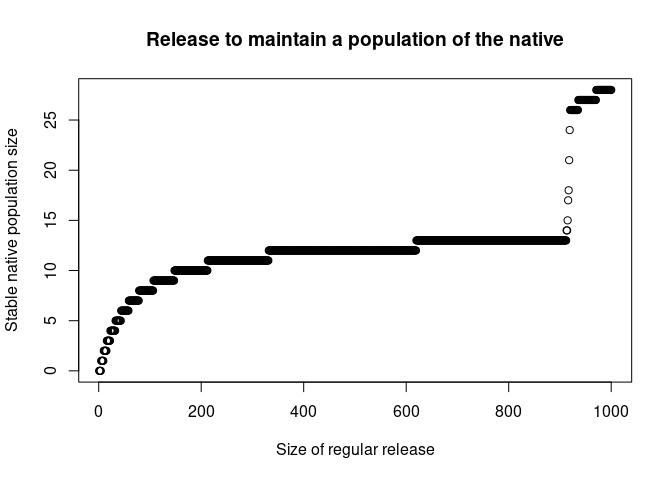

```r
# Let's plot the results.
plot(
        hx, res,
        xlab = "Size of regular release",
        ylab = "Stable native population size",
        main = "Release to maintain a population of the native",
)
```

[figure not shown]

Another way that we can improve the chances of the native mink is to increase the mortality rate of the invader. Since the only habitat patches that the native species is able to colonise are those which are empty (i.e. those vacated by death), increasing the rate of death increases the number of patches available to the native. This could be achieved via a culling program. We will look at this in the exercise.

There are some problems with this model. Firstly, it’s somewhat unrealistic to assume that the American mink will *always* be able to displace the European mink if they compete for habitat. The invasive may be larger *on average*, but there will be cases where a larger-than-average European mink is able to displace (or resist displacement by) an American mink. We could incorporate this into the model by allowing the natives to colonise some territories occupied by the invasive, and also by preventing the invasive from colonising *all* of the territories held by the native. Secondly, we know that human-caused disturbance will be impacting these populations too – we should really account for this. Also, it seems presumptuous to assume that the mortality rate of the mink is not part of the tradeoff that they make. I (Jonathan) will be incorporating all of these factors (and more) into this model as part of my PhD!

**Exercise:** What level of mortality for the invader produces a stable population of the native (hint: use the same method as we used above for the breed-and-release program)?

**Exercise:** What if we have differing mortality as well as breed-and-release? Can you come up with a method to do a cost-benefit analysis between culling and breed-and-release?

1. https://en.wikipedia.org/wiki/European_mink#Reproduction_and_development
2. Other modellers: I’m going to use simulation models of all these examples (even when analytic solutions exist) since I think it makes it clearer to less mathsy people what’s going on.
3. https://en.wikipedia.org/wiki/American_mink#Reproduction_and_development
4. https://en.wikipedia.org/wiki/American_mink#Decline_of_wild_mink
5. https://en.wikipedia.org/wiki/European_mink#Territorial_and_denning_behaviours